# Single Baseline Filtering and Power Spectrum Estimation

## Filtering and Systematics Mitigation

### Plotting Functions

```python
def sym_log_norm(to_plot, linthresh=10, clim=None):
    '''Convenience interface for matplotlib.colors.SymLogNorm'''
    if clim is None:
        return matplotlib.colors.SymLogNorm(linthresh, vmin=-np.nanmax(np.abs(to_plot)), vmax=np.nanmax(np.abs(to_plot)))
    else:
        return matplotlib.colors.SymLogNorm(linthresh, vmin=clim[0], vmax=clim[1])
```

```python
def plot_waterfall(data, bl=(ANTPAIR + ('ee',)), flags=flags, nsamples=nsamples, tslice=tslice):
    '''Plots data (amplitude and phase) as well as nsamples waterfalls for a baseline.'''
    if tslice is None:
        tslice = slice(0, data[bl].shape[0], 1)
    lsts = np.where(data.lsts > data.lsts[-1], data.lsts - 2 * np.pi, data.lsts)[tslice] * 12 / np.pi
    extent = [data.freqs[0]/1e6, data.freqs[-1]/1e6, lsts[-1], lsts[0]]

    fig, axes = plt.subplots(1, 3, figsize=(20, 12), sharex=True, sharey=True, dpi=100)
    im = axes[0].imshow(np.where(flags[bl], np.nan, np.abs(data[bl]))[tslice], aspect='auto', norm=matplotlib.colors.LogNorm(), interpolation='none', cmap='inferno', extent=extent)
    fig.colorbar(im, ax=axes[0], location='top', pad=.02, label=f'{bl}: Amplitude (Jy)')

    im = axes[1].imshow(np.where(flags[bl], np.nan, np.angle(data[bl]))[tslice], aspect='auto', cmap='twilight', interpolation='none', extent=extent)
    fig.colorbar(im, ax=axes[1], location='top', pad=.02, label=f'{bl}: Phase (Radians)')

    im = axes[2].imshow(nsamples[bl][tslice], aspect='auto', interpolation='none', extent=extent)
    fig.colorbar(im, ax=axes[2], location='top', pad=.02, label=f'{bl}: Number of Samples')
    plt.tight_layout()

    for ax in axes:
        ax.set_ylabel('LST (Hours)')
        ax.set_xlabel('Frequency (MHz)')
        with warnings.catch_warnings():
            warnings.simplefilter("ignore", UserWarning)
            ax.set_yticklabels([f'{(int(val) if np.isclose(val, int(val)) else val) % 24:n}' for val in ax.get_yticks()])

    plt.tight_layout()
```

```python
def plot_real_delay_vs_lst(data, bl=(ANTPAIR + ('ee',)), flags=None, xlim=[-1999, 1999], clim=None, linthresh=10, taper=TAPER, tslice=tslice):
    '''Plots the real part of the tapered FFT of the data in each power spectrum band as a function of delay and LST.'''
    if tslice is None:
        tslice = slice(0, data[bl].shape[0], 1)
    lsts = np.where(data.lsts > data.lsts[-1], data.lsts - 2 * np.pi, data.lsts)[tslice] * 12 / np.pi

    fig, axes = plt.subplots(1, len(bands), figsize=(28, 12), sharex=True, sharey=True, gridspec_kw={'wspace': .03}, dpi=100)
    for i, (ax, band, band_slice) in enumerate(zip(axes, bands, band_slices)):
        dfft = uvtools.utils.FFT(data[bl][tslice, band_slice], axis=1, taper=taper)
        delays = uvtools.utils.fourier_freqs(data.freqs[band_slice]) * 1e9
        to_plot = np.real(dfft)
        if flags is not None:
            flagged_times = np.all(flags[bl][tslice, band_slice], axis=1)
            to_plot[flagged_times, :] = np.nan
        if i == 0:
            _to_plot = copy.deepcopy(to_plot)
            ax.set_ylabel('LST (Hours)')
        im = ax.imshow(to_plot, interpolation='none', aspect='auto', cmap='bwr', norm=sym_log_norm(_to_plot, linthresh=linthresh, clim=clim),
                       extent=[delays[0], delays[-1], lsts[-1], lsts[0]])
        for dly in dly_filter_half_widths[0] * 1e9 * np.array([1, -1]):
            ax.axvline(dly, ls='--', color='k', lw=.5)
        for dly in inpaint_filter_half_widths[0] * 1e9 * np.array([1, -1]):
            ax.axvline(dly, ls=':', color='k', lw=.5)
        ax.set_xlim(xlim)
        ax.set_title(f'Band {i+1}:\n{band[0]}—{band[1]} MHz', fontsize=10)
        ax.set_xlabel('Delay (ns)')
        with warnings.catch_warnings():
            warnings.simplefilter("ignore", UserWarning)
            ax.set_yticklabels([f'{(int(val) if np.isclose(val, int(val)) else val) % 24:n}' for val in ax.get_yticks()])

    plt.colorbar(im, ax=axes, pad=.02, aspect=40, extend='both', label=f'Re$[\\widetilde{{V}}_{{{bl}}}]$ (Jy)')
```

```python
def plot_dly_vs_fr(data, bl=(ANTPAIR + ('ee',)), xlim=[-1999, 1999], ylim=[-5, 5], clim=None, tslice=tslice, taper=TAPER):
    '''Plots the magnitude of the 2D tapered FFT of the data in each power spectrum band as a function of delay and FR.
    Also shows the foreground filtering delay, the main beam range of FRs, and the expected shape of mutual coupling.'''
    fig, axes = plt.subplots(1, len(bands), figsize=(28, 6), sharex=True, sharey=True, gridspec_kw={'wspace': .03}, dpi=100)
    if tslice is None:
        tslice = slice(0, data[bl].shape[0], 1)

    to_plots = []
    for i, (ax, band, band_slice) in enumerate(zip(axes, bands, band_slices)):
        dfft = uvtools.utils.FFT(data[bl][:, band_slice], axis=1, taper=TAPER)
        delays = uvtools.utils.fourier_freqs(data.freqs[band_slice]) * 1e9
        frates = uvtools.utils.fourier_freqs((data.times[tslice] - data.times[0]) * 24 * 60 * 60) * 1000

        dfft2 = uvtools.utils.FFT(dfft[tslice, :], axis=0, taper=TAPER)

        to_plot = np.abs(dfft2)
        to_plots.append(to_plot)
        if i == 0:
            _to_plot = copy.deepcopy(to_plot)
            ax.set_ylabel('Fringe Rate (mHz)')
        im = ax.imshow(to_plot, interpolation='none', aspect='auto', cmap='turbo',
                       norm=matplotlib.colors.LogNorm(vmin=(clim[0] if clim is not None else np.min(_to_plot)),
                                                      vmax=(clim[1] if clim is not None else np.max(_to_plot))),
                       extent=[delays[0], delays[-1], frates[-1], frates[0]])
        for dly in dly_filter_half_widths[0] * 1e9 * np.array([1, -1]):
            ax.axvline(dly, ls='--', color='k', lw=.5)
        for dly in inpaint_filter_half_widths[0] * 1e9 * np.array([1, -1]):
            ax.axvline(dly, ls=':', color='k', lw=.5)
        for fr in fr_ranges[band]:# + (pol,)]:
            ax.axhline(fr, ls='--', color='k', lw=.5)

        ax.set_ylim(ylim)
        ax.set_xlim(xlim)
        ax.set_title(f'Band {i+1}:\n{band[0]}—{band[1]} MHz', fontsize=10)
        ax.set_xlabel('Delay (ns)')

    plt.colorbar(im, ax=axes, pad=.02, aspect=40, extend='both', label=f'$|\\widetilde{{V}}_{{{bl}}}|$ (Jy)')

    omega_earth = 2 * np.pi / (24 * 3600) #rad/s
    hera_dec = -30.72152612068925 * np.pi / 180
    def calculate_fr(bl_vec, freq):
        """bl_vec in meters, freq in Hz, returns fr in mHz"""
        bl_we = bl_vec[0]
        fr = -bl_we * omega_earth * freq * np.cos(hera_dec) / constants.c * 1e3
        return fr
    def max_fr(tau, freq):
        """takes in tau in ns, freq in Hz, returns corresponding max fringe rate in mHz"""
        return omega_earth * freq * tau * np.cos(hera_dec) * 1e-6 # mHz

    b_ij = data.antpos[bl[1]] - data.antpos[bl[0]]
    for i in range(len(bands)):
        freq = np.mean(bands[i]) * 1e6
        axes[i].plot(delays, max_fr(delays, freq) + calculate_fr(b_ij, freq), color='k', ls='--', lw=.5)
        axes[i].plot(delays, -max_fr(delays, freq) + calculate_fr(b_ij, freq), color='k', ls='--', lw=.5)
```

### Filtering and Post-Processing Functions

```python
def delay_filter(
    data,
    wgts,
    filter_centers,
    filter_half_widths,
    eigenval_cutoff,
    cache={},
    bls=None,
    zeros_where_zero_wgt=True,
    plot_zero_gaps=False,
    plot_fit=False,
):
    '''This function performs a high-pass delay filter, removing the wedge plus
    some buffer. It also performs inpainting with the same delay.

    If plot_fit=True, plot the DPSS fit for the first LST/time sample
    that has at least one non-zero weight.

    Spectral-window boundaries from BAND_STR are shown on the diagnostic
    plots as vertical lines, with the gaps between spectral windows shaded.
    '''

    dly_filt_data = copy.deepcopy(data)
    inpainted_data = copy.deepcopy(data)

    if bls is None:
        bls = cross_bls

    # ------------------------------------------------------------
    # Parse spectral-window boundaries from BAND_STR
    # ------------------------------------------------------------
    spectral_windows = []

    for window in BAND_STR.split(","):
        lo, hi = window.split("~")
        spectral_windows.append((float(lo), float(hi)))

    # ------------------------------------------------------------
    # Helper for plotting spectral-window boundaries
    # ------------------------------------------------------------
    def add_spectral_window_boundaries(ax, alpha=0.7):
        for i, (lo, hi) in enumerate(spectral_windows):

            # Vertical lines at both edges of every spectral window
            ax.axvline(
                lo,
                linestyle="--",
                linewidth=1.0,
                alpha=alpha,
            )

            ax.axvline(
                hi,
                linestyle="--",
                linewidth=1.0,
                alpha=alpha,
            )

            # Shade the gaps BETWEEN spectral windows
            if i < len(spectral_windows) - 1:
                next_lo = spectral_windows[i + 1][0]

                ax.axvspan(
                    hi,
                    next_lo,
                    alpha=0.08,
                    zorder=0,
                )

    for bl in bls:

        # ------------------------------------------------------------
        # Plot zero-weight locations in the low and high bands
        # ------------------------------------------------------------
        if plot_zero_gaps:
            fig, axes = plt.subplots(
                2, 1,
                figsize=(14, 8),
                sharex=False
            )

            for ax, band, band_name in zip(
                axes,
                [low_band, high_band],
                ["Low band", "High band"]
            ):
                if band.start >= band.stop:
                    ax.set_title(f"{band_name} — empty")
                    continue

                freqs = data.freqs[band] / 1e6
                weights = wgts[bl][:, band]
                zero_mask = weights == 0

                im = ax.imshow(
                    zero_mask,
                    aspect="auto",
                    origin="lower",
                    extent=[
                        freqs[0],
                        freqs[-1],
                        0,
                        zero_mask.shape[0]
                    ]
                )

                # Spectral-window boundaries
                add_spectral_window_boundaries(ax)

                ax.set_xticks(np.arange(
                    np.ceil(freqs[0] / 5) * 5,
                    freqs[-1] + 5,
                    5
                ))

                ax.set_ylabel("Time index")
                ax.set_title(
                    f"{band_name} — Zero Weight locations — baseline {bl}"
                )

                fig.colorbar(
                    im,
                    ax=ax,
                    label="Zero Weight"
                )

            axes[-1].set_xlabel("Frequency [MHz]")

            fig.suptitle(
                f"Zero Weight / spectral-window diagnostic — baseline {bl}",
                fontsize=14
            )

            plt.tight_layout()
            plt.show()

        # ------------------------------------------------------------
        # Find first LST that is NOT completely flagged
        # ------------------------------------------------------------
        if plot_fit:
            valid_lst = np.any(wgts[bl] != 0, axis=1)

            if not np.any(valid_lst):
                print(
                    f"No LST with non-zero weights found for baseline {bl}"
                )
                plot_lst = None

            else:
                plot_lst = np.flatnonzero(valid_lst)[0]

                n_valid = np.count_nonzero(
                    wgts[bl][plot_lst] != 0
                )
                n_total = wgts[bl][plot_lst].size

                print(
                    f"Plotting first partially/unflagged LST for baseline "
                    f"{bl}: time index {plot_lst} "
                    f"({n_valid}/{n_total} channels weighted)"
                )

        # ------------------------------------------------------------
        # Perform filtering
        # ------------------------------------------------------------

        d_mdl = np.zeros_like(dly_filt_data[bl])

        for band in [low_band, high_band]:

            if band.start >= band.stop:
                continue

            d_mdl[:, band], _, info = dspec.fourier_filter(
                data.freqs[band],
                dly_filt_data[bl][:, band],
                wgts=wgts[bl][:, band],
                filter_centers=filter_centers,
                filter_half_widths=filter_half_widths,
                mode='dpss_solve',
                eigenval_cutoff=[eigenval_cutoff],
                suppression_factors=[eigenval_cutoff],
                max_contiguous_edge_flags=len(data.freqs),
                cache=cache
            )

        # ------------------------------------------------------------
        # Plot the fit for the first LST with any valid data
        # ------------------------------------------------------------
        if plot_fit and plot_lst is not None:
```

```python
            fig, axes = plt.subplots(
                2, 1,
                figsize=(15, 10),
                sharex=False
            )

            for ax, band, band_name in zip(
                axes,
                [low_band, high_band],
                ["Low band", "High band"]
            ):
                if band.start >= band.stop:
                    ax.set_title(f"{band_name} — empty")
                    continue

                freqs = data.freqs[band] / 1e6

                d = data[bl][plot_lst, band]
                mdl = d_mdl[plot_lst, band]
                res = d - mdl
                w = wgts[bl][plot_lst, band]

                valid = w != 0
                flagged = ~valid

                # ----------------------------------------------------
                # Main curves
                # ----------------------------------------------------
                ax.plot(
                    freqs,
                    np.real(d),
                    label="Data",
                    linewidth=1.2,
                    alpha=0.8,
                )

                ax.plot(
                    freqs,
                    np.real(mdl),
                    label="DPSS fit",
                    linewidth=2.0,
                )

                ax.plot(
                    freqs,
                    np.real(res),
                    label="Residual",
                    linewidth=1.0,
                    alpha=0.7,
                )

                # ----------------------------------------------------
                # Spectral-window boundaries and gaps
                # ----------------------------------------------------
                add_spectral_window_boundaries(ax)

                # ----------------------------------------------------
                # Highlight zero-weight channels
                # ----------------------------------------------------
                if np.any(flagged):

                    ymin, ymax = ax.get_ylim()
                    marker_y = ymin + 0.05 * (ymax - ymin)

                    ax.scatter(
                        freqs[flagged],
                        np.full(
                            np.count_nonzero(flagged),
                            marker_y
                        ),
                        marker="x",
                        s=35,
                        label="Zero weight",
                        zorder=5,
                    )

                    # Shade contiguous zero-weight regions
                    flagged_idx = np.where(flagged)[0]

                    starts = flagged_idx[
                        np.r_[
                            True,
                            np.diff(flagged_idx) > 1
                        ]
                    ]

                    ends = flagged_idx[
                        np.r_[
                            np.diff(flagged_idx) > 1,
                            True
                        ]
                    ]

                    for start, end in zip(starts, ends):
                        ax.axvspan(
                            freqs[start],
                            freqs[end],
                            alpha=0.12,
                            zorder=0,
                        )

                # ----------------------------------------------------
                # Formatting
                # ----------------------------------------------------
                n_valid_band = np.count_nonzero(valid)
                n_total_band = len(w)

                ax.set_ylabel("Real amplitude")

                ax.set_title(
                    f"{band_name} — "
                    f"{n_valid_band}/{n_total_band} channels weighted"
                )

                ax.grid(
                    True,
                    alpha=0.25,
                    linestyle="--",
                )

                ax.legend(
                    loc="best",
                    frameon=True,
                )

            axes[-1].set_xlabel("Frequency [MHz]")

            fig.suptitle(
                f"DPSS fit diagnostic — baseline {bl}, "
                f"first non-zero-weight LST "
                f"(time index {plot_lst})",
                fontsize=15,
            )

            plt.tight_layout()
            plt.show()

            # --------------------------------------------------------
            # Additional residual-only plot
            # --------------------------------------------------------
            fig, axes = plt.subplots(
                2, 1,
                figsize=(15, 7),
                sharex=False
            )

            for ax, band, band_name in zip(
                axes,
                [low_band, high_band],
                ["Low band", "High band"]
            ):
                if band.start >= band.stop:
                    continue

                freqs = data.freqs[band] / 1e6

                d = data[bl][plot_lst, band]
                mdl = d_mdl[plot_lst, band]
                res = d - mdl
                w = wgts[bl][plot_lst, band]

                valid = w != 0

                ax.plot(
                    freqs[valid],
                    np.real(res[valid]),
                    linewidth=1.2,
                    label="Residual",
                )

                if np.any(~valid):
                    ax.scatter(
                        freqs[~valid],
                        np.real(res[~valid]),
                        marker="x",
                        s=35,
                        label="Zero weight",
                    )

                # Spectral-window boundaries
                add_spectral_window_boundaries(ax)

                ax.axhline(
                    0,
                    linewidth=0.8,
                    linestyle="--",
                )

                ax.set_ylabel("Data − DPSS fit")
                ax.set_title(f"{band_name} residual")

                ax.grid(
                    True,
                    alpha=0.25,
                    linestyle="--",
                )
```

```python
                ax.legend()

            axes[-1].set_xlabel("Frequency [MHz]")

            fig.suptitle(
                f"DPSS residual — baseline {bl}, "
                f"time index {plot_lst}",
                fontsize=14,
            )

            plt.tight_layout()
            plt.show()

        # ------------------------------------------------------------
        # Subtract model
        # ------------------------------------------------------------

        if zeros_where_zero_wgt:
            dly_filt_data[bl] = np.where(
                wgts[bl] == 0,
                0,
                dly_filt_data[bl] - d_mdl
            )
        else:
            dly_filt_data[bl] = (
                dly_filt_data[bl] - d_mdl
            )

        inpainted_data[bl] = np.where(
            wgts[bl] == 0,
            d_mdl,
            data[bl]
        )

    return dly_filt_data, inpainted_data
```

```python
def xtalk_filter(data, wgts, xtalk_fr=XTALK_FR, tslice=tslice, cache={}, bls=None):
    '''This function performs a high-pass filter in fringe rate, removing some small range around the 0 FR mode.'''
    xtalk_filt_data = copy.deepcopy(data)
    if bls is None:
        bls = cross_bls

    for bl in bls:
        if tslice is None:
            tslice = slice(0, data[bl].shape[0], 1)

        d_mdl, _, info = dspec.fourier_filter(data.times[tslice] * 24 * 60 * 60, data[bl][tslice],
                                              wgts=wgts[bl][tslice, :], filter_centers=[0],
                                              filter_half_widths=[xtalk_fr / 1000], mode='dpss_solve',
                                              eigenval_cutoff=[FR_EIGENVAL_CUTOFF], suppression_factors=[FR_EIGENVAL_CUTOFF],
                                              max_contiguous_edge_flags=len(data.times), cache=cache, filter_dims=0)

        out = xtalk_filt_data[bl].copy()
        out[tslice, :] = np.where(wgts[bl][tslice, :] == 0, 0, xtalk_filt_data[bl][tslice, :] - d_mdl)
        xtalk_filt_data[bl] = out
    return xtalk_filt_data
```

```python
def main_beam_FR_filter(data, wgts, tslice=tslice, cache={}, bls=None):
    '''This function performs fringe rate filtering, keeping a range determined by fr_ranges for each band.'''
    frf_data = copy.deepcopy(data)
    if bls is None:
        bls = cross_bls

    info = {}
    for bl in bls:
        if tslice is None:
            tslice = slice(0, data[bl].shape[0], 1)

        info[bl] = {}
        d_mdl = np.zeros_like(data[bl])
        for band, band_slice in zip(bands, band_slices):
            d_mdl[tslice, band_slice], _, info_band = dspec.fourier_filter(
                data.times[tslice] * 24 * 60 * 60,
                data[bl][tslice, band_slice],
                wgts=wgts[bl][tslice, band_slice],
                filter_centers=[np.mean(fr_ranges[band]) / 1000],
                filter_half_widths=[np.diff(fr_ranges[band]) / 2 / 1000],
                mode='dpss_solve',
                eigenval_cutoff=[FR_EIGENVAL_CUTOFF],
                suppression_factors=[FR_EIGENVAL_CUTOFF],
                max_contiguous_edge_flags=len(data.times),
                cache=cache,
                filter_dims=0
            )
            info[bl][band] = info_band

        frf_data[bl] *= 0
        out = np.zeros_like(frf_data[bl])
        out[tslice, :] = np.where(wgts[bl][tslice, :] == 0, 0.0, d_mdl[tslice, :])
        frf_data[bl] = out

    return frf_data, info
```

```python
def form_pseudostokes(data=None, flags=None, nsamples=None, pol_convention=hd.pol_convention, x_orientation=hd.telescope.get_x_orientation_from_feeds()):
    '''This function uses hera_pspec.pstokes to supplement existing datacontainers with pstokes I, Q, U, and/or V (where possible).'''
    for ap in data.antpairs():
        # loop over pseudo-stokes parameters
        iter_list = [('ee', 'nn', 'pI'), ('ee', 'nn', 'pQ'), ('en', 'ne', 'pU'), ('en', 'ne', 'pV')]
        for pol1, pol2, pstokes in iter_list:
            bl1 = ap + (pol1,)
            bl2 = ap + (pol2,)
            data_list = ([data[bl1], data[bl2]] if (data is not None) and (bl1 in data) and (bl2 in data) else None)
            flags_list = ([flags[bl1], flags[bl2]] if (flags is not None) and (bl1 in flags) and (bl2 in flags) else None)
            nsamples_list = ([nsamples[bl1], nsamples[bl2]] if (nsamples is not None) and (bl1 in nsamples) and (bl2 in nsamples) else None)

            # use hp.pstokes._combine_pol_arrays() to properly combine data/flags/nsamples in a pol_convention-aware way
            (combined_data,
             combined_flags,
             combined_nsamples) = hp.pstokes._combine_pol_arrays(pol1, pol2, pstokes,
                                                                 pol_convention=pol_convention,
                                                                 data_list=data_list,
                                                                 flags_list=flags_list,
                                                                 nsamples_list=nsamples_list,
                                                                 x_orientation=x_orientation)
            # put results in original data containers
            if data is not None:
                data[ap + (pstokes,)] = combined_data
            if flags is not None:
                flags[ap + (pstokes,)] = combined_flags
            if nsamples is not None:
                nsamples[ap + (pstokes,)] = combined_nsamples
```

```python
def timeavg_data(data, flags, nsamples, Navg=int(np.round(AVERAGING_TIME / (dt * NINTERLEAVE))), pols=None, tslice=slice(None), rephase=True):
    '''Performs coherent averaging of Navg integrations, rephasing to the common phase center.'''
    avg_data = datacontainer.DataContainer({})
    avg_flags = datacontainer.DataContainer({})
    avg_nsamples = datacontainer.DataContainer({})

    # perform time-averaging
    for bl in data:
        if (pols is not None) and (bl[2] not in pols):
            continue
        bl_vec =  data.antpos[bl[0]] - data.antpos[bl[1]]
        (avg_data[bl],
         avg_flags[bl],
         avg_nsamples[bl],
         avg_lsts,
         extra) = frf.timeavg_waterfall(data[bl][tslice, :], Navg,
                                        flags=np.zeros_like(flags[bl][tslice, :]),
                                        nsamples=nsamples[bl][tslice, :],
                                        extra_arrays={'times': data.times[tslice]},
                                        lsts=data.lsts[tslice], freqs=data.freqs,
                                        rephase=rephase, bl_vec=bl_vec, verbose=False)
        avg_flags[bl][avg_nsamples[bl] == 0] = True # TODO: is this right???

    # attach relevant quantities to datacontainer
    for dc in (avg_data, avg_flags, avg_nsamples):
        dc.freqs = copy.deepcopy(data.freqs)
        dc.antpos = copy.deepcopy(data.antpos)
        dc.lsts = avg_lsts
        dc.times = extra['avg_times']
    return avg_data, avg_flags, avg_nsamples
```

### Figure out delay filter properties

```python
bl_vec = (data.antpos[ANTPAIR[1]] - data.antpos[ANTPAIR[0]])
bl_len = np.linalg.norm(bl_vec[:2]) / constants.c
dly_filter_centers, dly_filter_half_widths = vis_clean.gen_filter_properties(
    ax='freq', horizon=DLY_FILT_HORIZON, standoff=DLY_FILT_STANDOFF,
    min_dly=DLY_FILT_MIN_DLY, bl_len=bl_len
)
inpaint_filter_centers, inpaint_filter_half_widths = vis_clean.gen_filter_properties(
    ax='freq', horizon=INPAINT_HORIZON, standoff=INPAINT_STANDOFF,
    min_dly=INPAINT_MIN_DLY, bl_len=bl_len
)

OUT_BL_DELAY_RANGE_FILE = "hw.csv"

if PERFORM_DLY_FILT:
    with open(OUT_BL_DELAY_RANGE_FILE, "w") as file:
        file.write(f"BL_HW_(s), {max(DLY_FILT_HORIZON * bl_len *1e9 + DLY_FILT_STANDOFF, DLY_FILT_MIN_DLY)}\n")
```

### If desired, propagate flags on a channel to all times that will be coherently averaged together

This is primarily useful in the delay-filtered case with flags, where we want to avoid different interleaves having different flagging patterns.

```python
def factored_flags(flag_array, tslice=slice(None)):
    '''If any channel is flagged in a boolean flag_array, flag all times for that channel unless the channel flag comes from an entirely flagged time.'''
    out_flags = np.zeros_like(flag_array)
    flagged_times = np.all(flag_array, axis=1)
    out_flags[flagged_times, :] = True
    if not np.all(flagged_times) :
        chan_flags = np.any(flag_array[~flagged_times], axis=0)
        out_flags[:, chan_flags] = True
    return out_flags

if FLAG_COHERENT_CHUNKS:
    Nchunk = int(AVERAGING_TIME // (dt * NINTERLEAVE)) * NINTERLEAVE
    for ci in range(int(np.ceil(flags[bl][tslice].shape[0] / Nchunk))):
        for bl in flags:
            flags[bl][tslice][ci * Nchunk:(ci + 1) * Nchunk] = factored_flags(flags[bl][tslice][ci * Nchunk:(ci + 1) * Nchunk], tslice=tslice)
```

### Perform inpainting and/or delay-filtering

```python
def per_band_avg_nsamples(nsamples, flags, band_slices):
    '''Create new datacontainer where nsamples has been averaged per-integration in band_slices.
    This is an approximate way to account for the fact that inpainted data is considered Nsamples=0.'''
    out_nsamples = copy.deepcopy(nsamples)
    for bl in out_nsamples:
        for band in band_slices:
            for i in range(out_nsamples[bl].shape[0]):
                out_nsamples[bl][i, band] = np.mean(out_nsamples[bl][i, band]) * (~np.any(flags[bl][i, band])).astype(float)
    return out_nsamples
```

```python
def build_weights(data, flags, nsamples, wgt_by_avg_nsamples=False, band_slices=[]):
    '''Construct weights proportional to inverse noise variance (i.e. Nsamples / Autocorr^2).
    If wgt_by_avg_nsamples is True, average Nsamples in each subband (defined with band_slices).
    This avoids the introduction of spectral structure.'''
    wgts = copy.deepcopy(data)
    if wgt_by_avg_nsamples:
        nsamples_here = per_band_avg_nsamples(nsamples, flags, band_slices)
    else:
        nsamples_here = copy.deepcopy(nsamples)

    for bl in wgts:
        auto_bl = auto_antpair + bl[2:]
        wgts[bl] = np.where(flags[bl], 0, np.abs(data[auto_bl])**-2 * nsamples_here[bl])
        wgts[bl] /= np.abs(np.nanmean(np.where(flags[bl], np.nan, wgts[bl])))  # avoid dynamic range issues
        wgts[bl][~np.isfinite(wgts[bl])] = 0

    return wgts
```

```python
# Build weights for delay-filter and/or inpainting that don't involve any Nsample averaging
freq_filt_wgts = build_weights(data, flags, nsamples)

for bl in freq_filt_wgts:
    freq_filt_wgts[bl][:, fm_gap] = 0
```

```python
# Inpaint autocorrelations to allow for prediction of thermal noise on every channel
for bl in [auto_antpair + (pol,) for pol in ['ee', 'nn']]:
    x = data[bl]

    print(f"\n{bl}")
    print("NaNs:", np.isnan(x).sum())
    print("Infs:", np.isinf(x).sum())
    print("finite:", np.isfinite(x).sum())
    print("min:", np.nanmin(x))
    print("max:", np.nanmax(x))
if not ALREADY_INPAINTED:
    _, data = delay_filter(data, freq_filt_wgts, inpaint_filter_centers, inpaint_filter_half_widths, INPAINT_EIGENVAL_CUTOFF,
                           bls=[auto_antpair + (pol,) for pol in ['ee', 'nn']])
```

```
(0, 0, 'ee')
NaNs: 147036
Infs: 0
finite: 6132132
min: 0j
max: (4803772.956301084+0j)

(0, 0, 'nn')
NaNs: 147036
Infs: 0
finite: 6132132
min: 0j
max: (4017489.736897892+0j)
```

```python
filt_data = copy.deepcopy(data)
filt_flags = copy.deepcopy(flags)
filt_nsamples = copy.deepcopy(nsamples)
```

```python
# This cell replaces data with appropriate noise, which is useful for debugging
if USE_SIMULATED_NOISE:
    np.random.seed(21)

    reds = redcal.get_reds(filt_data.data_antpos, pols=filt_data.pols(), include_autos=True, bl_error_tol=2.0)
    red_inpainted = datacontainer.RedDataContainer(data, reds=reds)

    for bl in cross_bls:
        predicted_var = noise.predict_noise_variance_from_autos(bl, red_inpainted, nsamples=nsamples)
        predicted_var = np.where(~np.isfinite(predicted_var), 0, predicted_var)
        filt_data[bl] = np.sqrt(predicted_var) / 2**.5 * (np.random.randn(hd.Ntimes, hd.Nfreqs) + 1.0j * np.random.randn(hd.Ntimes, hd.Nfreqs))
```

```python
# Inpaint crosses
if PERFORM_INPAINT:
    _, filt_data = delay_filter(data, freq_filt_wgts, inpaint_filter_centers, inpaint_filter_half_widths, INPAINT_EIGENVAL_CUTOFF, plot_zero_gaps=True)
    for bl in cross_bls:
        for band in [high_band, low_band]:
            if band.start >= band.stop:
                continue
            for i in range(filt_flags[bl].shape[0]):
                if not np.all(filt_flags[bl][i, band]):
                    filt_flags[bl][i, band] = False
inpainted = copy.deepcopy(filt_data)
```

```
[np.float64(5.0000000000000004e-08)]
Plotting first partially/unflagged LST for baseline (0, 1, 'ne'): time index 685 (1193/1536 channels weighted)
```

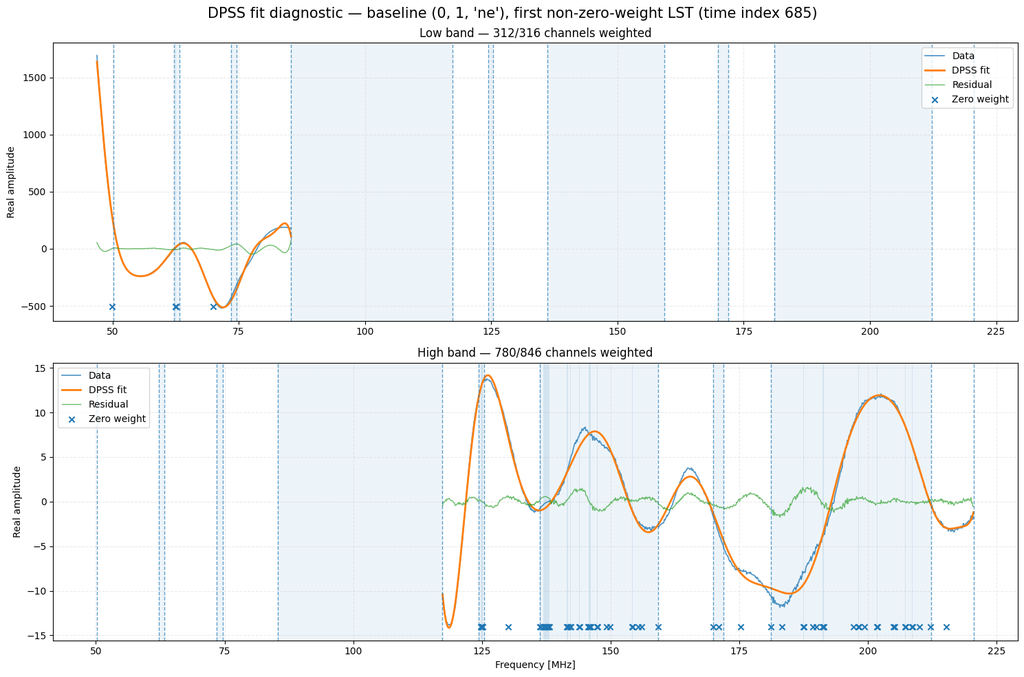

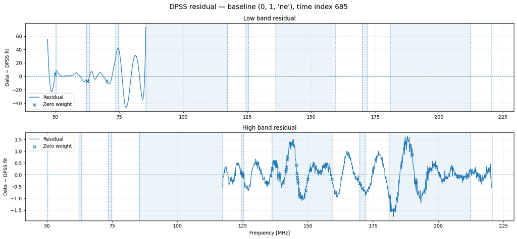

```
Plotting first partially/unflagged LST for baseline (0, 1, 'en'): time index 685 (1193/1536 channels weighted)
```

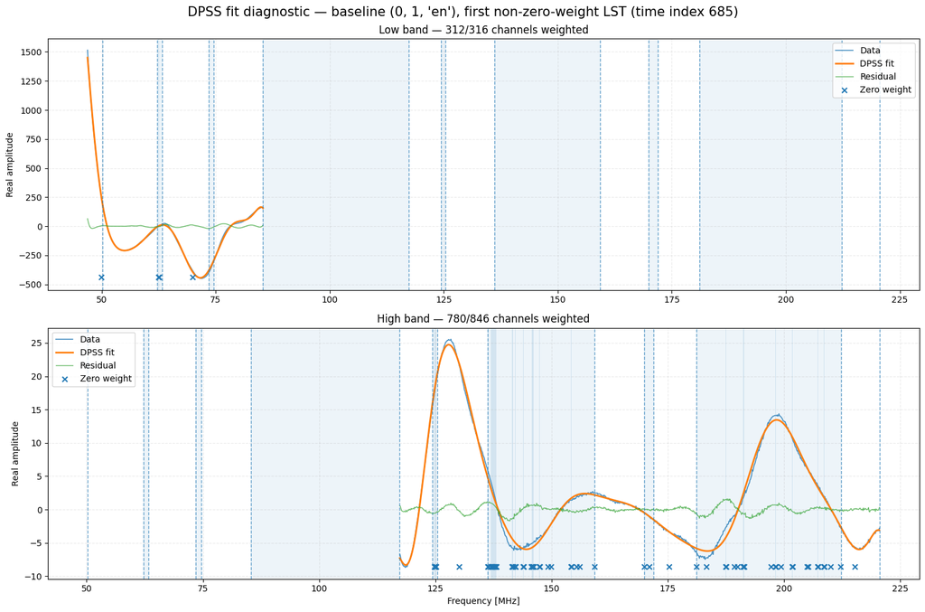

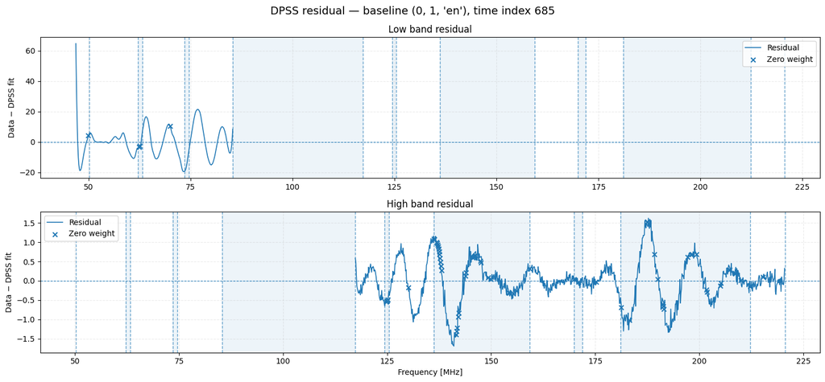

```
Plotting first partially/unflagged LST for baseline (0, 1, 'ee'): time index 685 (1193/1536 channels weighted)
```

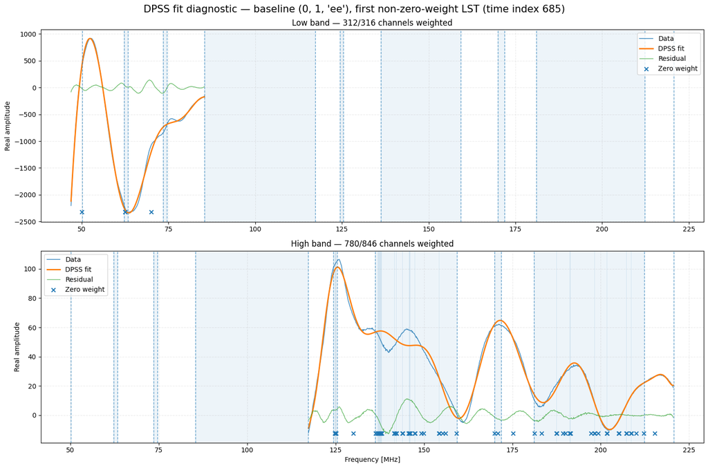

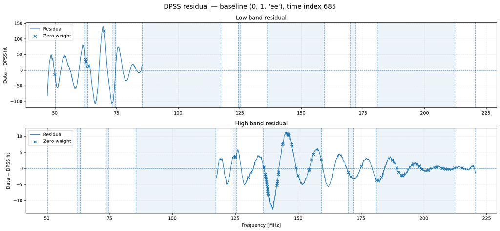

```
Plotting first partially/unflagged LST for baseline (0, 1, 'nn'): time index 685 (1193/1536 channels weighted)
```

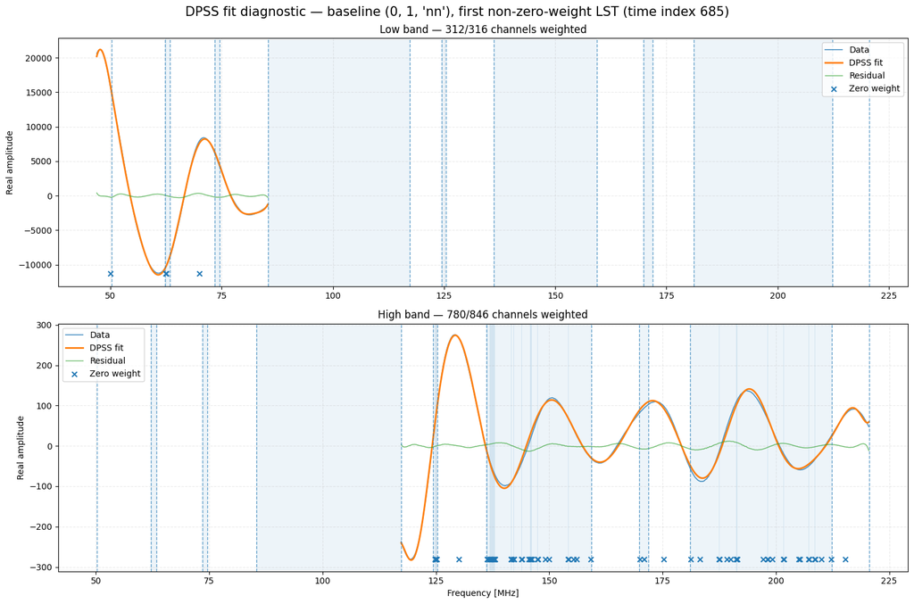

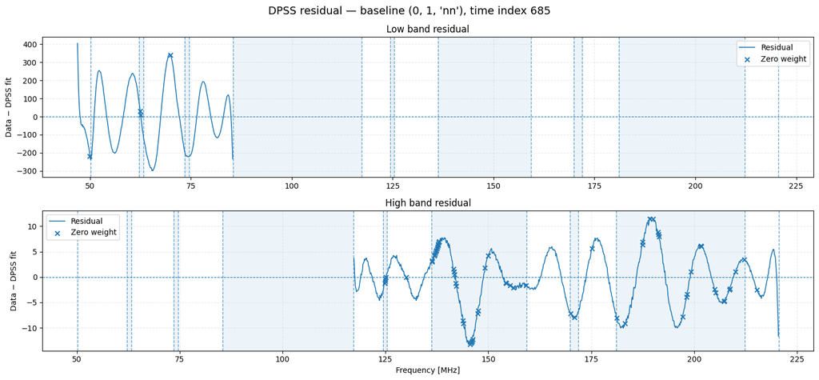

```python
# perform delay filtering on crosses
print(dly_filter_half_widths)
if PERFORM_DLY_FILT:
    filt_data, _ = delay_filter(
        inpainted,
        freq_filt_wgts,
        dly_filter_centers,
        dly_filter_half_widths,
        DLY_FILT_EIGENVAL_CUTOFF,
        zeros_where_zero_wgt=False,
        plot_fit=True
    )
```

```python
# Recompute time filter flags, averaging nsamples in subbands if desired (this also applies to further processing)
if USE_BAND_AVG_NSAMPLES:
    filt_nsamples = per_band_avg_nsamples(filt_nsamples, filt_flags, band_slices)

time_filt_wgts = build_weights(filt_data, filt_flags, filt_nsamples)
```

```python
# perform deinterleaving
deint_filt_data = filt_data.deinterleave(NINTERLEAVE, tslice=tslice)
deint_flags = filt_flags.deinterleave(NINTERLEAVE, tslice=tslice)
deint_nsamples = filt_nsamples.deinterleave(NINTERLEAVE, tslice=tslice)
deint_wgts = time_filt_wgts.deinterleave(NINTERLEAVE, tslice=tslice)
```

### Figure out per-band fringe-rate filter ranges

```python
# TODO: graduate this code into hera_cal

# load relevant FR spectrum vs. frequency and associated metadata
with h5py.File(FR_SPECTRA_FILE, "r") as h5f:
    metadata = h5f["metadata"]
    bl_to_index_map = {tuple(ap): int(index) for index, antpairs in metadata["baseline_groups"].items() for ap in antpairs}
    spectrum_freqs = metadata["frequencies_MHz"][()] * 1e6
    m_modes = metadata["erh_mode_integer_index"][()]
    if ANTPAIR in bl_to_index_map:
        mmode_spectrum = h5f["erh_mode_power_spectrum"][:, :, bl_to_index_map[ANTPAIR]]
    else:
        # If ANTPAIR is not in the FR_SPECTRA_FILE, but the reverse is, also reverse the spectrum
        mmode_spectrum = h5f["erh_mode_power_spectrum"][:, :, bl_to_index_map[ANTPAIR[::-1]]]
        m_modes *= -1
```

```python
# Compute the band-averaged m-mode spectra.
interp_spec = interpolate.interp1d(spectrum_freqs, mmode_spectrum, kind="cubic", axis=1, fill_value="extrapoloate")(data.freqs)
band_avg_spec = {}
for band, bs in zip(bands, band_slices):
    taper = dspec.gen_window(TAPER, len(data.freqs[bs]))
    band_avg_spec[band] = np.average(interp_spec[:,bs], weights=taper**2, axis=1)
```

```python
# Make one set of mixing matrices for the high resolution times for filter design.
full_times = data.times[tslice]
times_ks = (full_times - full_times[0] + np.median(np.diff(full_times))) * units.day.to(units.ks)
filt_frates = np.fft.fftshift(np.fft.fftfreq(times_ks.size, d=np.median(np.diff(times_ks))))
_m2f_mixer = frf.get_m2f_mixer(times_ks, m_modes)

# Use the deinterleaved time series for signal loss calculation.
deint_times = deint_filt_data[0].times
times_ks = (deint_times - deint_times[0] + np.median(np.diff(deint_times))) * units.day.to(units.ks)
frates = np.fft.fftshift(np.fft.fftfreq(times_ks.size, d=np.median(np.diff(times_ks))))
m2f_mixer = frf.get_m2f_mixer(times_ks, m_modes)
```

```python
# TODO: graduate this code into hera_cal
# perform window-weighted average over each band, then get lower and upper quantiles
fr_ranges = {}
fr_profiles = {}
frf_losses = {}
xtalk_overlaps = {}
for band in bands:
    m_mode_spec = band_avg_spec[band]

    # Compute the filter bounds.
    band_avg_fr_spectrum = np.abs(np.einsum("fm,m,mf->f", _m2f_mixer, m_mode_spec, _m2f_mixer.T.conj()))
    band_avg_fr_spectrum /= np.sum(band_avg_fr_spectrum)
    cumsum_interpolator = interpolate.interp1d(np.cumsum(band_avg_fr_spectrum), filt_frates)
    fr_ranges[band] = cumsum_interpolator(FR_QUANTILE_LOW), cumsum_interpolator(FR_QUANTILE_HIGH)

    # Now compute the fringe-rate profile to be used for signal loss calculations.
    band_avg_fr_spectrum = np.abs(np.einsum("fm,m,mf->f", m2f_mixer, m_mode_spec, m2f_mixer.T.conj()))
    band_avg_fr_spectrum /= np.sum(band_avg_fr_spectrum)
    fr_profiles[band] = band_avg_fr_spectrum

    # account for overlap between FR=0 notch and main beam FRF
    def overlap_frs(frs1, frs2):
        start = np.maximum(frs1[0], frs2[0])
        end = np.minimum(frs1[1], frs2[1])
        return (start, end) if start < end else None
    frate_interpolator = interpolate.interp1d(frates, np.cumsum(band_avg_fr_spectrum), fill_value="extrapolate")
    frf_losses[band] = 1 - frate_interpolator(fr_ranges[band][1]) + frate_interpolator(fr_ranges[band][0])
    xtalk_overlaps[band] = overlap_frs(fr_ranges[band], [-XTALK_FR, XTALK_FR])
    if xtalk_overlaps[band] is not None:
        frf_losses[band] += frate_interpolator(xtalk_overlaps[band][1]) - frate_interpolator(xtalk_overlaps[band][0])
```

```python
# Helper fft functions for signal loss calculation.
def FFT(data, axis):
    """Thin wrapper around fft stuff."""
    return np.fft.fftshift(np.fft.fft(np.fft.ifftshift(data, axes=axis), axis=axis), axes=axis)

def IFFT(data, axis):
    """Thin wrapper around ifft stuff."""
    return np.fft.ifftshift(np.fft.ifft(np.fft.fftshift(data, axes=axis), axis=axis), axes=axis)
```

```python
# TODO: incorporate coherent average and time-interleaving to signal loss calculation.

# Update frf signal loss calculation.
frf_losses = {}
filter_design_matrices = {}
for band, band_slice in zip(bands, band_slices):
    # TODO: figure out how to handle frequency and polarization-dependent weights.
    # The weights change as a function of frequency (due to the inverse noise weighting),
    # so this isn't entirely accurate; will need to update in the future.
    # Also need to more carefully consider how to combine the weights across polarization,
    # and which precise set of weights to use when filtering the data.
    wgts = np.mean([deint_wgts[0][bl][:,band_slice] for bl in cross_bls if bl[2][0] == bl[2][1]], axis=(0,2))

    if np.all(wgts==0):
        frf_losses[band] = np.nan
        continue

    # Compute the filter center and filter half-width.
    fmin, fmax = fr_ranges[band]
    fc = 0.5 * (fmin+fmax)  # mHz
    fhw = 0.5 * np.abs(fmax-fmin)  # mHz

    # Generate the main-lobe and crosstalk time-time filter matrices.
    main_lobe_filt = frf.construct_filter(times_ks, fc, fhw, eigval_cutoff=FR_EIGENVAL_CUTOFF, wgts=wgts)
    xt_filt = np.eye(times_ks.size) - frf.construct_filter(times_ks, 0, XTALK_FR, eigval_cutoff=FR_EIGENVAL_CUTOFF, wgts=wgts)

    # Fourier transform to obtain the fringe-rate filter matrices.
    filter_xfer_matrix = FFT(IFFT(main_lobe_filt @ xt_filt, axis=0), axis=1)
    filter_design_matrices[band] = filter_xfer_matrix

    # Now compute the signal loss.
    filtered_power = np.sum(fr_profiles[band][None,:] * np.abs(filter_xfer_matrix)**2)
    unfiltered_power = np.sum(fr_profiles[band])
    frf_losses[band] = 1 - filtered_power / unfiltered_power
```

```python
def show_FR_table():
    table = pd.DataFrame({'Band': np.arange(len(bands)) + 1,
                          'Frequency Range (MHz)': [f'{f0:.1f} — {f1:.1f}' for f0, f1 in zip(min_freqs, max_freqs)],
                          f'Main Beam {FR_QUANTILE_LOW:.0%} — {FR_QUANTILE_HIGH:.0%}<br>Kept Fringe Rates (mHz)': [f'{frs[0]:.3f} to {frs[1]:.3f}' for frs in fr_ranges.values()],
                          f'Signal Loss with<br>{-XTALK_FR} to {XTALK_FR} mHz X-Talk Filter': [f'{loss:.1%}' for loss in frf_losses.values()],
                         })
    return table.style.hide().to_html()
```

### *Table 2: Fringe-Rate and Crosstalk Filtering Ranges and Losses*

The losses computed here are based on an extension of the framework from [Pascua+ 2025](https://iopscience.iop.org/article/10.3847/1538-4357/adc37d) to allow for non-uniform time weighting. These losses include contributions from both the main beam filter and the crosstalk filter, but do not include losses from coherent time averaging or the time-interleaved incoherent average.

```python
HTML(show_FR_table())
```

| Band | Frequency Range (MHz) | Main Beam 5% — 95% Kept Fringe Rates (mHz) | Signal Loss with -0.01 to 0.01 mHz X-Talk Filter |
| --- | --- | --- | --- |
| 1 | 50.2 — 62.2 | -0.266 to -0.099 | 8.4% |
| 2 | 63.3 — 73.5 | -0.323 to -0.077 | 8.4% |
| 3 | 74.6 — 85.4 | -0.379 to -0.122 | 5.2% |
| 4 | 117.3 — 124.4 | -0.541 to -0.228 | 2.8% |
| 5 | 125.4 — 136.2 | -0.576 to -0.252 | 2.8% |
| 6 | 159.3 — 169.9 | -0.714 to -0.323 | 2.5% |
| 7 | 171.9 — 181.1 | -0.761 to -0.348 | 2.5% |
| 8 | 212.3 — 220.6 | -0.914 to -0.438 | 2.7% |

```python
# precomputation for rephasing before coherent averaging, ensuring all interleaves are rephased to the same lst
bl_vec = {bl: data.antpos[bl[0]] - data.antpos[bl[1]] for bl in [ap + (pol,) for ap in data.antpairs()
                                                                 for pol in (utils._VISPOLS | set(utils.POL_STR2NUM_DICT))]}
for bl in list(bl_vec.keys()):
    if bl[0] != bl[1]:
        bl_vec[(bl[1], bl[0], bl[2])] = -bl_vec[bl]
Navg = int(AVERAGING_TIME // (dt * NINTERLEAVE))
n_avg_int = int(np.ceil(len(deint_filt_data[0].lsts) / Navg))
target_lsts = [np.mean(np.unwrap(np.sort(np.ravel([d.lsts[i * Navg:(i+1) * Navg] for d in deint_filt_data])))) for i in range(n_avg_int)]
```

### Run time filtering, time averaging, and form pseudo-Stokes

```python
# Initialize arrays for storing intermediate and final results for each interleave
deint_avg_data, deint_avg_flags, deint_avg_nsamples = [], [], []
deint_xtalk_filt_data, deint_frf_data = [], []

# List of dicts saying whether main lobe FRF was skipped or not
FRF_info = []
for d, f, n, w in zip(deint_filt_data, deint_flags, deint_nsamples, deint_wgts):
    # Perform full time-filtering
    if not SKIP_XTALK_AND_FRF:
        # Crosstalk filtering of FR=0 mode
        xtalk_filt_d = xtalk_filter(d, w, tslice=None)
        deint_xtalk_filt_data.append(xtalk_filt_d)

        # Main beam FRF and forming pseduostokes
        frf_d, info_stream = main_beam_FR_filter(xtalk_filt_d, w, tslice=None)
        FRF_info.append(info_stream)
        deint_frf_data.append(frf_d)
    else:
        deint_xtalk_filt_data.append(d)
        deint_frf_data.append(d)

    # Coherent time-averaging, rephasing to a set of lsts that's consistent across interleaves
    dlst = [target_lsts[i] - l for i in range(n_avg_int) for l in np.unwrap(d.lsts)[i * Navg:(i+1) * Navg]]
    rephased_frf_d = copy.deepcopy(deint_frf_data[-1])
    utils.lst_rephase(rephased_frf_d, bl_vec, d.freqs, dlst, lat=hd.telescope.location_lat_lon_alt_degrees[0], inplace=True)

    pstokes_pols = sorted([pol for pol in rephased_frf_d.pols() if utils.polstr2num(pol, x_orientation=hd.telescope.get_x_orientation_from_feeds()) > 0])
    avg_d, avg_f, avg_n = timeavg_data(rephased_frf_d, f, n, Navg=int(AVERAGING_TIME // (dt * NINTERLEAVE)), rephase=False)

    # Form pseudo-Stokes I, Q, U, and V from ee and nn
    form_pseudostokes(avg_d, avg_f, avg_n)

    # Store Results
    deint_avg_data.append(avg_d)
    deint_avg_flags.append(avg_f)
    deint_avg_nsamples.append(avg_n)
```

## Estimate total signal loss from FRF and coherent time average

```python
# Retrieve the baseline vector and array latitude.
baseline = bl_vec[ANTPAIR + ("pI",)]
lat = hd.telescope.location.lat.rad

# Convert the pre-/post-average times to seconds
old_times = deint_filt_data[0].times
old_times = (old_times - old_times[0]) * units.day.to(units.s)
new_times = np.array(deint_avg_data[0].times)
new_times = (new_times - deint_filt_data[0].times[0]) * units.day.to(units.s)
new_inttime = AVERAGING_TIME
```

```python
frf_plus_tavg_losses = {}

for band, band_slice in zip(bands, band_slices):
    wgts = np.mean([deint_wgts[0][bl][:,band_slice] for bl in cross_bls if bl[2][0] == bl[2][1]], axis=(0,2))

    if np.all(wgts==0):
        frf_plus_tavg_losses[band] = np.nan
        continue

    # Retrieve the FRF filter matrix.
    filter_xfer_matrix = filter_design_matrices[band]

    # Compute the band-averaged FR profile.
    freqs = data.freqs[band_slice]
    avg_spec = band_avg_spec[band]
    fr_profile = np.diag(m2f_mixer @ (avg_spec[:,None] * m2f_mixer.T.conj()))

    # Compute the filtered fringe-rate profile and convert to a time-time covariance.
    filt_cov = FFT(IFFT(filter_xfer_matrix @ (fr_profile[:,None] * filter_xfer_matrix.T.conj()), axis=1), axis=0)

    # Retrieve n_samples and flags for this band.
    n_samples = deint_nsamples[0][ANTPAIR]['nn'][:,band_slice] + deint_nsamples[0][ANTPAIR]['ee'][:,band_slice]
    _flags = deint_flags[0][ANTPAIR]['ee'][:,band_slice] | deint_flags[0][ANTPAIR]['nn'][:,band_slice]

    # Take the band-averaged n_samples and flags to avoid NaNs from fully-flagged channels.
    n_samples = n_samples.mean(axis=1)
    _flags = _flags.mean(axis=1).astype(bool)

    # Compute the time-average design matrix at the center of the band.
    design_mat = frf.get_coherent_avg_design_matrix(
        baseline, lat, freqs.mean(), old_times, new_times, n_samples, new_inttime, _flags
    )[0]

    # Now compute the signal loss.
    filtered_power = np.abs(filt_cov * (design_mat.T @ design_mat.conj())).sum() / design_mat.shape[0]
    unfiltered_power = np.abs(fr_profile).mean()
    frf_plus_tavg_losses[band] = 1 - filtered_power / unfiltered_power
```

```python
def show_loss_table():
    table = pd.DataFrame({'Band': np.arange(len(bands)) + 1,
                          'Frequency Range (MHz)': [f'{f0:.1f} — {f1:.1f}' for f0, f1 in zip(min_freqs, max_freqs)],
                          f'Main Beam {FR_QUANTILE_LOW:.0%} — {FR_QUANTILE_HIGH:.0%}<br>Kept Fringe Rates (mHz)': [f'{frs[0]:.3f} to {frs[1]:.3f}' for frs in fr_ranges.values()],
                          f'Signal Loss with<br>{-XTALK_FR} to {XTALK_FR} mHz X-Talk Filter': [f'{loss:.1%}' for loss in frf_losses.values()],
                          f'Signal Loss with<br>{int(AVERAGING_TIME)} s Coherent Average': [f'{loss:.1%}' for loss in frf_plus_tavg_losses.values()],
                         })
    return table.style.hide().to_html()
```

```python
HTML(show_loss_table())
```

| Band | Frequency Range (MHz) | Main Beam 5% — 95% Kept Fringe Rates (mHz) | Signal Loss with -0.01 to 0.01 mHz X-Talk Filter | Signal Loss with 270 s Coherent Average |
| --- | --- | --- | --- | --- |
| 1 | 50.2 — 62.2 | -0.266 to -0.099 | 8.4% | 8.0% |
| 2 | 63.3 — 73.5 | -0.323 to -0.077 | 8.4% | 8.0% |
| 3 | 74.6 — 85.4 | -0.379 to -0.122 | 5.2% | 4.9% |
| 4 | 117.3 — 124.4 | -0.541 to -0.228 | 2.8% | 2.7% |
| 5 | 125.4 — 136.2 | -0.576 to -0.252 | 2.8% | 2.9% |
| 6 | 159.3 — 169.9 | -0.714 to -0.323 | 2.5% | 2.7% |
| 7 | 171.9 — 181.1 | -0.761 to -0.348 | 2.5% | 2.7% |
| 8 | 212.3 — 220.6 | -0.914 to -0.438 | 2.7% | 3.1% |